# Praca domowa 2

Roksana Rogalska

## Dane

Dane wykorzystane w Pracy domowej 2 są związane z kampaniami marketingu bezpośredniego portugalskiej instytucji bankowej. Kampanie marketingowe opierały się na rozmowach telefonicznych. Często wymagany był więcej niż jeden kontakt z tym samym klientem, aby uzyskać dostęp do tego, czy produkt (lokata bankowa) zostanie (lub nie) subskrybowany. Opis wszystkich kolumn znajduje się również w pliku `README.md`.

#### Dane klienta banku

| Zmienna | Opis |
| --- | --- |
| **age** | wiek |
| **job** : admin., unknown, unemployed, management, housemaid, entrepreneur, student, blue-collar, self-employed, retired, technician, services | administrator, nieznany, bezrobotny, kierownictwo, pokojówka, przedsiębiorca, student, pracownik fizyczny, samozatrudniony, emeryt, technik, usługi |
| **marital** : married, divorced, single; note: divorced means divorced or widowed) | żonaty/zamężna, rozwiedzion_, kawaler/panna; uwaga: rozwiedzion_ oznacza rozwiedzion_ lub owdowiał_ |
| **education** : unknown, secondary, primary, tertiary | nieznane, średnie, podstawowe, wyższe |
| **default** : yes, no | czy kredyt jest niespłacany : tak, nie |
| **balance** : average yearly balance, in euros | średnie roczne saldo w euro |
| **housing** : has housing loan? yes, no | czy posiada kredyt mieszkaniowy? tak, nie |
| **loan** : has personal loan? yes, no | ma pożyczkę osobistą? tak, nie |

#### Dane związane z ostatnim kontaktem w bieżącej kampanii

| Zmienna | Opis |
| --- | --- |
| **contact** : unknown, telephone, cellular | nieznany, telefon, komórkowy |
| **day** : last contact day of the month | dzień miesiąca ostatniego kontaktu |
| **month** : last contact month of year, jan, feb, mar, …, nov, dec | miesiąc ostatniego kontaktu w roku, styczeń, luty, marzec, …, listopad, grudzień |
| **duration** : last contact duration, in seconds | czas trwania ostatniego kontaktu w sekundach |

## Zadanie 1

Weźmy pod uwagę zawody (`job`) klientów banku. Który zawód zacząco wyróżnia się w posiadaniu kredytu mieszkaniowego lub pożyczki osobistej?

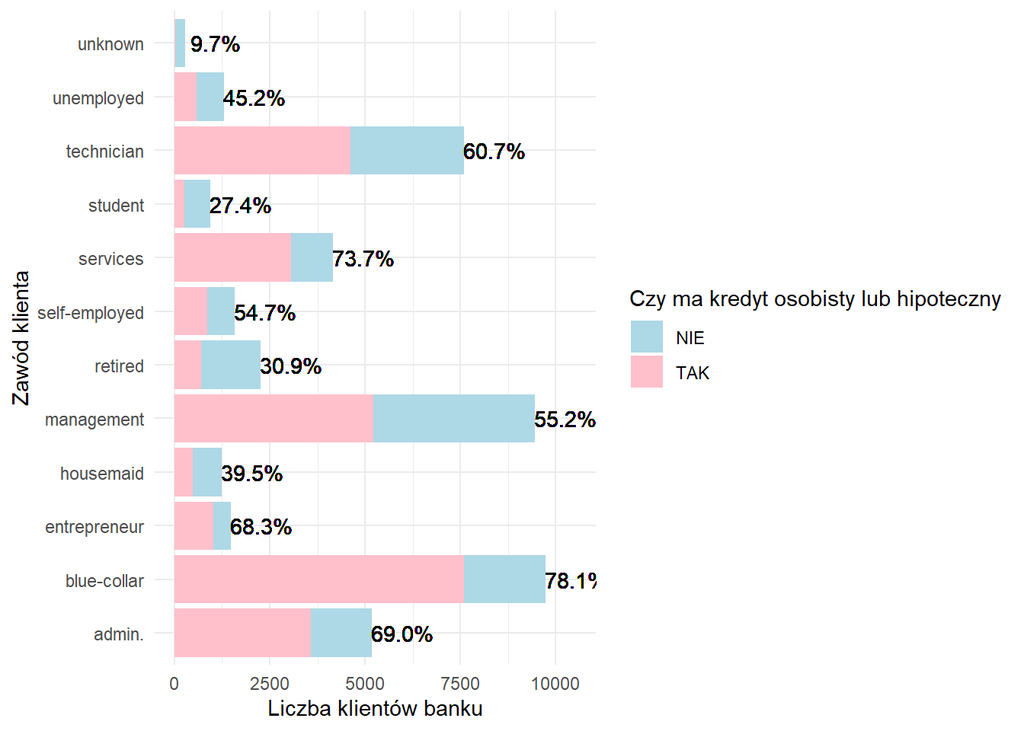

```r
# Tu umieść kod do wygenerowania odpowiedzi do zadania.
data <- df %>%
  mutate(
    loan_or_housing = ifelse(loan == 'yes' | housing == 'yes', 'TAK', 'NIE')
    )

ratios <- data %>% group_by(job) %>% mutate(
  total = n(),
  loans = sum(1 * (loan_or_housing == 'TAK')),
  others = sum(1* (loan_or_housing == 'NIE')),
  ratio = sprintf("%.1f%%", 100*loans / total)
)

data %>%
  ggplot(aes(y=job, fill = loan_or_housing)) +
  geom_bar() +
  geom_text(
    data=ratios,
    aes(x=total + 800, y=job, label=ratio),
    inherit.aes = FALSE
    ) +
  theme_minimal() +
  labs(
    fill="Czy ma kredyt osobisty lub hipoteczny",
    x="Liczba klientów banku",
    y="Zawód klienta") +
  scale_fill_manual(values = c("NIE" = "lightblue", "TAK" = "pink"))
```

**Komentarz:** Wyróżnia się grupa pracowników fizycznych, z najwyższą liczbą i najwyższym procentem.

## Zadanie 2

Wybierając klientów, którzy mają nieznany sposób kontaktu (`contact`). Jak rozkłada się ich wiek w podziale na status związku?

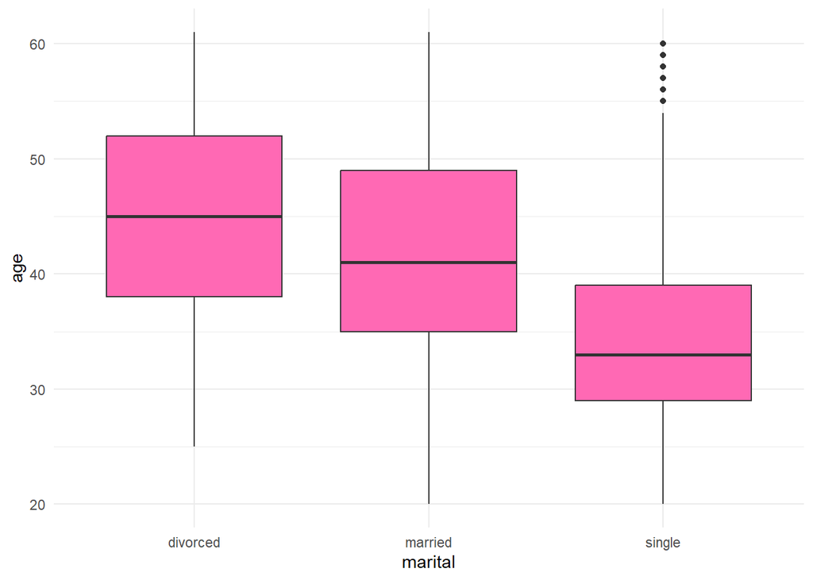

```r
# Tu umieść kod do wygenerowania odpowiedzi do zadania.
df %>%
  filter(contact == 'unknown') %>%
  ggplot(aes(x = marital, y = age)) +
  geom_boxplot(fill = 'hotpink') +
  theme_minimal()
```

Jaka jest różnica pomiędzy średnim rocznym saldem w euro w zależności od wykształcenia i tego czy kredyt jest niespłacany?

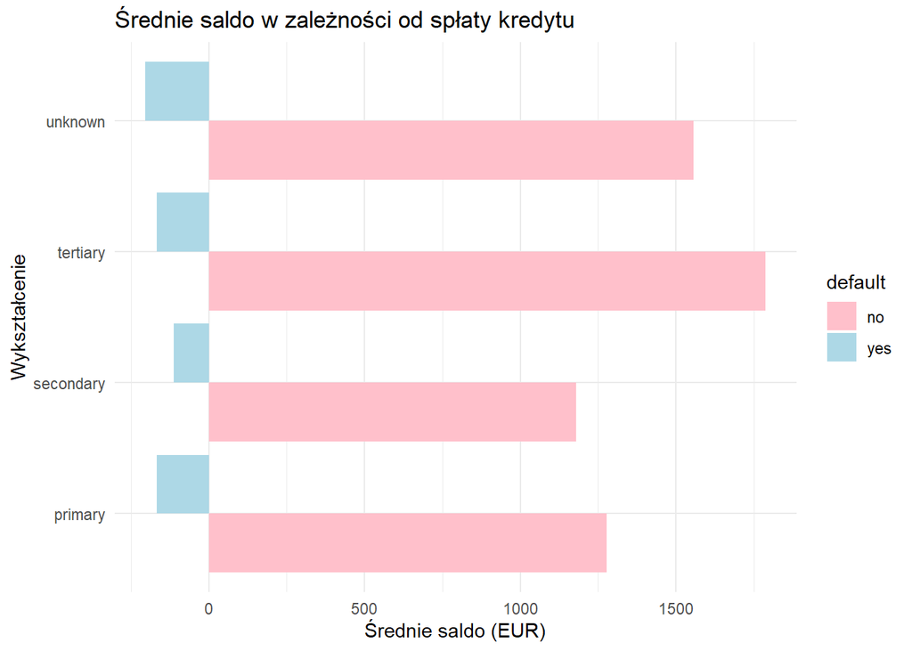

```r
# Tu umieść kod do wygenerowania odpowiedzi do zadania.
df %>%
  group_by(education, default) %>%
  summarise(mean_balance = mean(balance)) %>%
  ggplot(aes(x = mean_balance, y = education, fill=default)) +
  geom_bar(stat = "identity", position = "dodge") +
  theme_minimal() +
  labs(
    title = "Średnie saldo w zależności od spłaty kredytu",
    x = "Średnie saldo (EUR)",
    y = "Wykształcenie"
  ) +
  scale_fill_manual(values = c("yes" = "lightblue", "no" = "pink"))
```

**Komentarz:** Największa różnica występuje wsród osób z wyższym wykształceniem, najmniejsza wśród osób ze średnim wykształceniem.

## Zadanie 4

Czy dzień i miesiąc kontaktu z klientem ma wpływ na średni czas trwania rozmowy w stosunku do średniego czasu trwania rozmowy?

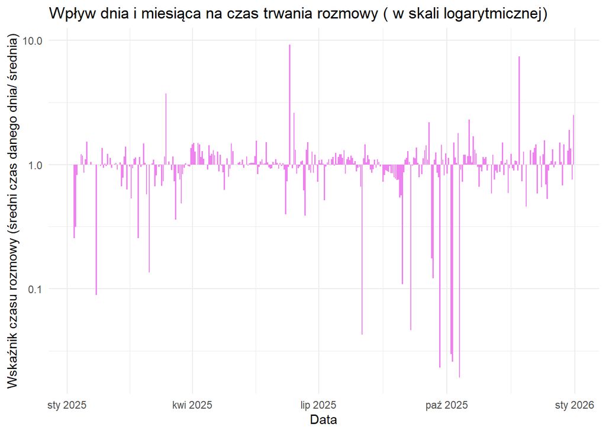

```r
# Tu umieść kod do wygenerowania odpowiedzi do zadania.
mean_all <- mean(df$duration)

df %>%
  group_by(day, month) %>%
  summarise(mean_duration = mean(duration)) %>%
  mutate(index = mean_duration / mean_all) %>%
  mutate(
    month_num = case_when(
      month == "jan" ~ 1,
      month == "feb" ~ 2,
      month == "mar" ~ 3,
      month == "apr" ~ 4,
      month == "may" ~ 5,
      month == "jun" ~ 6,
      month == "jul" ~ 7,
      month == "aug" ~ 8,
      month == "sep" ~ 9,
      month == "oct" ~ 10,
      month == "nov" ~ 11,
      month == "dec" ~ 12,
      TRUE ~ NA
    ),
    date = as.Date(paste( month_num, day, sep = "-"), format = "%m-%d")
  ) %>%
  arrange(date) %>%
  ggplot(aes(x = date, y = index)) +
  geom_col(fill = 'violet') +
  labs(
    title = "Wpływ dnia i miesiąca na czas trwania rozmowy ( w skali logarytmicznej)",
       x = "Data",
       y = "Wskaźnik czasu rozmowy (średni czas danego dnia/ średnia)"
    ) +
  scale_y_log10() + theme_minimal()
```

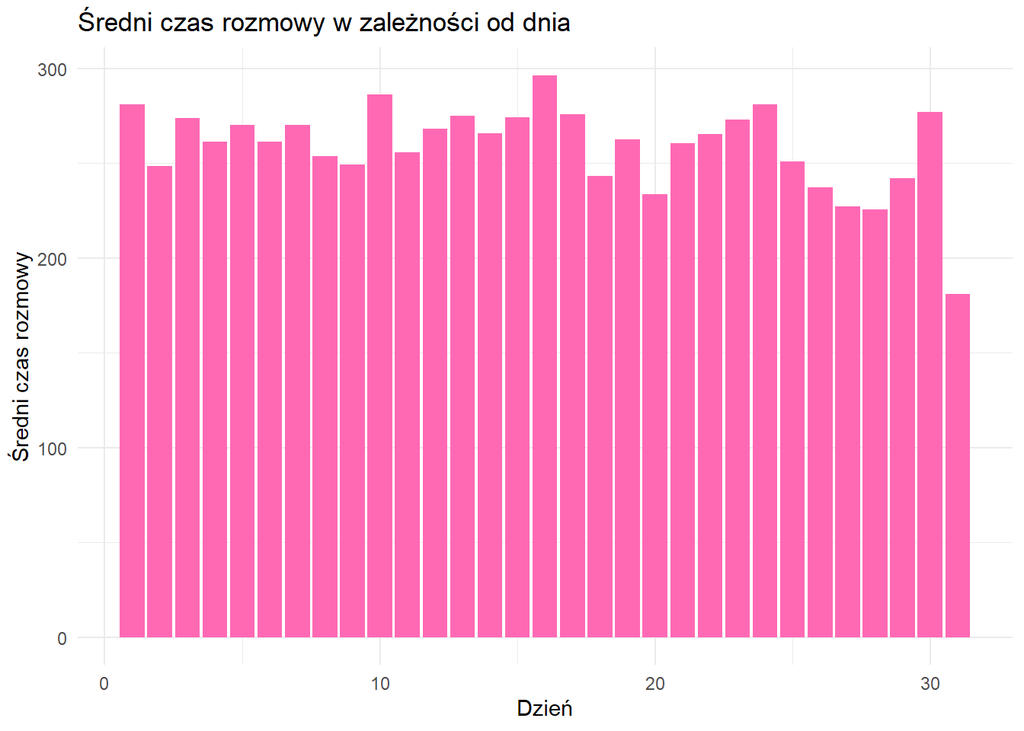

```r
df %>%
  group_by(day) %>%
  summarise(mean_duration = mean(duration)) %>%
  ggplot(aes(x = day, y = mean_duration)) +
  geom_col(fill = 'hotpink') +
  labs(
    title = "Średni czas rozmowy w zależności od dnia",
    x = "Dzień",
    y = "Średni czas rozmowy"
  ) +
  theme_minimal()
```

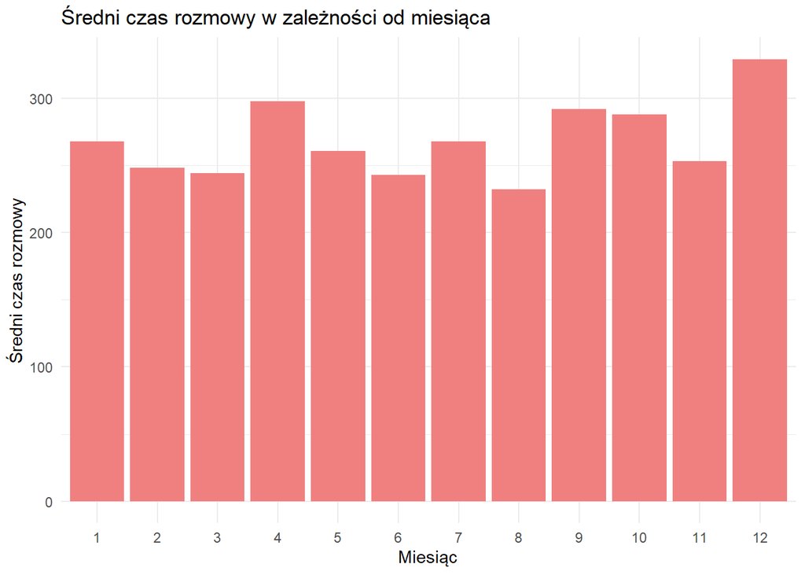

```r
df %>%
  group_by(month) %>%
  summarise(mean_duration = mean(duration)) %>%
  mutate(
    month_num = case_when(
      month == "jan" ~ 1,
      month == "feb" ~ 2,
      month == "mar" ~ 3,
      month == "apr" ~ 4,
      month == "may" ~ 5,
      month == "jun" ~ 6,
      month == "jul" ~ 7,
      month == "aug" ~ 8,
      month == "sep" ~ 9,
      month == "oct" ~ 10,
      month == "nov" ~ 11,
      month == "dec" ~ 12,
      TRUE ~ NA
    )) %>%
  arrange(desc(month_num)) %>%
  ggplot(aes(x = as.factor(month_num), y = mean_duration)) +
  geom_col(fill = 'lightcoral') +
  labs(
    title = "Średni czas rozmowy w zależności od miesiąca",
    x = "Miesiąc",
    y = "Średni czas rozmowy"
  ) +
  theme_minimal()
```

## Zadanie 5

Czy jest zależnośc pomiędzy wiekiem klientów a ich średnim rocznym saldzie w euro w podziale na stopień wykształcenia?

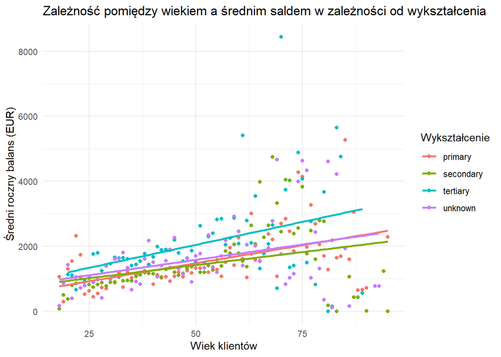

```r
# Tu umieść kod do wygenerowania odpowiedzi do zadania.
df %>%
  group_by(age, education) %>%
  summarise(mean_balance = mean(balance)) %>%
  filter(mean_balance < 20000) %>% # usunięcie outliera psusjącego skale
  ggplot(aes(x = age, y = mean_balance, color = education)) +
  geom_point() +
  geom_smooth(method="lm", se=FALSE) +
  labs(
    title = "Zależność pomiędzy wiekiem a średnim saldem w zależności od wykształcenia",
    x = "Wiek klientów",
    y = "Średni roczny balans (EUR)",
    color = "Wykształcenie"
  ) +
  theme_minimal()
```

## Zadanie 6

Rozważmy osoby, które są bezrobotne albo ich zawód jest nieznany. Czy procent osób, które są bezrobotne i nie spłacają kredytu jest większy od procenta osób o nieznanym zawodzie i nie spłacanym kredycie? Jaki typ kredytu jest (przez te osoby) najczęściej niespłacany?

```r
# Tu umieść kod do wygenerowania odpowiedzi do zadania.
library(tidyr)
```

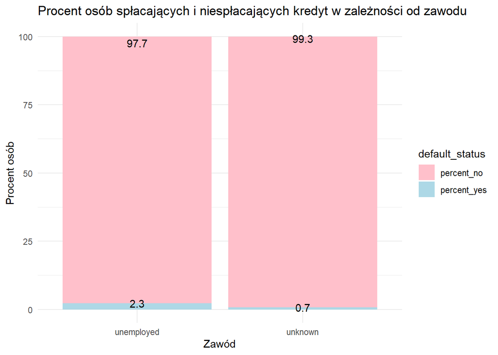

```r
df %>%
  filter(job == 'unemployed' | job == 'unknown') %>%
  group_by(job, default) %>%
  summarise(n = n()) %>%
  pivot_wider(names_from = default, values_from = n) %>%
  mutate(
    sum = no + yes,
    percent_yes = yes/sum*100,
    percent_no = no/sum*100
    )  %>%
  pivot_longer(
    cols = c(percent_yes, percent_no),
    names_to = "default_status",
    values_to = "percentage"
    ) %>%
  ggplot(
    aes(x = job,
        y = percentage,
        fill = default_status)
    ) +
  geom_col() +
  geom_text(
    aes(x=job,
        y=percentage,
        label=round(percentage, 1))
    )+
  scale_fill_manual(values = c("percent_yes" = "lightblue", "percent_no" = "pink")) +
  labs(
    title = "Procent osób spłacających i niespłacających kredyt w zależności od zawodu",
    y = "Procent osób",
    x = "Zawód"
  ) + theme_minimal()
```

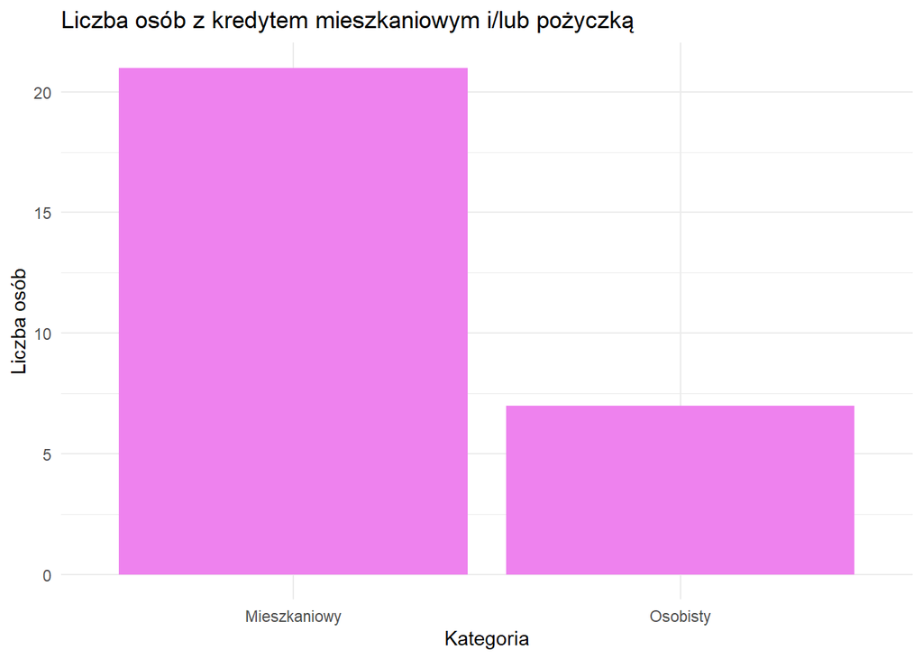

```r
df %>%
  filter(job == 'unemployed' | job == 'unknown',
         default == 'yes',
         housing == 'yes' | loan =='yes') %>%
  summarise(housing_yes = sum(housing == 'yes'),
            loan_yes = sum(loan == 'yes')) %>%
  pivot_longer(cols = everything(), names_to = "category", values_to = "count") %>%
  ggplot(aes(x = category, y = count)) +
  geom_col(fill='violet') +
  labs(title = "Liczba osób z kredytem mieszkaniowym i/lub pożyczką",
       x = "Kategoria",
       y = "Liczba osób") +
  theme_minimal() +
  scale_x_discrete(labels = c("housing_yes" = "Mieszkaniowy", "loan_yes" = "Osobisty"))
```

**Komentarz:** Więcej osób bezrobotnych nie spłaca kredytu, więcej jest kredytów mieszkaniowych.